# Uber - Fare Price Prediction System

### Dataset Used -> **[Kaggle - Uber Fares Dataset](https://www.kaggle.com/datasets/yasserh/uber-fares-dataset)**

#### **Description:**

Uber is one of the world's largest ridesharing company, providing millions of rides to customers daily. In this project, we will analyze Uber's historical transactional data to build a model for predicting ride fares.

#### **Goal:** 🎯

Our goal is to identify key features that correlate with ride fares and build a model to predict **fare prices**. We will train algorithms on this data to create a robust fare price prediction system.

# I. Importing Required Dependencies

```python
import numpy as np
import pandas as pd
import matplotlib.pyplot as plt
import seaborn as sns

import warnings
warnings.filterwarnings(action = 'ignore')

from sklearn.model_selection import train_test_split

from sklearn.linear_model import LinearRegression
from sklearn.tree import DecisionTreeRegressor
from sklearn.ensemble import RandomForestRegressor
from sklearn.ensemble import GradientBoostingRegressor

from sklearn.metrics import r2_score

import joblib
```

## II. Loading the Dataset

```python
uber = pd.read_csv('uber.csv', parse_dates = ['pickup_datetime'])
uber.head()
```

|  | Unnamed: 0 | key | fare_amount | pickup_datetime | pickup_longitude | pickup_latitude | dropoff_longitude | dropoff_latitude | passenger_count |
| --- | --- | --- | --- | --- | --- | --- | --- | --- | --- |
| 0 | 24238194 | 2015-05-07 19:52:06.0000003 | 7.5 | 2015-05-07 19:52:06+00:00 | -73.999817 | 40.738354 | -73.999512 | 40.723217 | 1 |
| 1 | 27835199 | 2009-07-17 20:04:56.0000002 | 7.7 | 2009-07-17 20:04:56+00:00 | -73.994355 | 40.728225 | -73.994710 | 40.750325 | 1 |
| 2 | 44984355 | 2009-08-24 21:45:00.00000061 | 12.9 | 2009-08-24 21:45:00+00:00 | -74.005043 | 40.740770 | -73.962565 | 40.772647 | 1 |
| 3 | 25894730 | 2009-06-26 08:22:21.0000001 | 5.3 | 2009-06-26 08:22:21+00:00 | -73.976124 | 40.790844 | -73.965316 | 40.803349 | 3 |
| 4 | 17610152 | 2014-08-28 17:47:00.000000188 | 16.0 | 2014-08-28 17:47:00+00:00 | -73.925023 | 40.744085 | -73.973082 | 40.761247 | 5 |

```python
uber.info()
```

```
<class 'pandas.core.frame.DataFrame'>
RangeIndex: 200000 entries, 0 to 199999
Data columns (total 9 columns):
 #   Column             Non-Null Count   Dtype
---  ------             --------------   -----
 0   Unnamed: 0         200000 non-null  int64
 1   key                200000 non-null  object
 2   fare_amount        200000 non-null  float64
 3   pickup_datetime    200000 non-null  datetime64[ns, UTC]
 4   pickup_longitude   200000 non-null  float64
 5   pickup_latitude    200000 non-null  float64
 6   dropoff_longitude  199999 non-null  float64
 7   dropoff_latitude   199999 non-null  float64
 8   passenger_count    200000 non-null  int64
dtypes: datetime64[ns, UTC](1), float64(5), int64(2), object(1)
memory usage: 13.7+ MB
```

# III. Data Wrangling

#### 1. Dropping Unwanted Fields

`Dropping the fields 'Unnamed: 0' and 'key' as they are not required.`

```python
uber.drop(['Unnamed: 0', 'key'], axis = 'columns' , inplace = True)

# At first glance the dataset has almost no null values
uber.isnull().sum()
```

```
fare_amount          0
pickup_datetime      0
pickup_longitude     0
pickup_latitude      0
dropoff_longitude    1
dropoff_latitude     1
passenger_count      0
dtype: int64
```

#### 2. Dealing with Null Values

##### Caveats found in Dataset

- Null Values are represented by **zeroes**.

`As per the dataset, uber transactions are done at 0 Latitude and Longitude, which is not correct`

[figure not shown]

```python
uber.replace(0, None, inplace = True)
uber.isnull().sum()
```

```
fare_amount             5
pickup_datetime         0
pickup_longitude     3786
pickup_latitude      3782
dropoff_longitude    3765
dropoff_latitude     3759
passenger_count       709
dtype: int64
```

```python
print(uber.info())

uber['fare_amount'] = uber['fare_amount'].astype(float)
uber['passenger_count'] = uber['passenger_count'].astype(float)
```

```
<class 'pandas.core.frame.DataFrame'>
RangeIndex: 200000 entries, 0 to 199999
Data columns (total 7 columns):
 #   Column             Non-Null Count   Dtype
---  ------             --------------   -----
 0   fare_amount        199995 non-null  object
 1   pickup_datetime    200000 non-null  datetime64[ns, UTC]
 2   pickup_longitude   196214 non-null  object
 3   pickup_latitude    196218 non-null  object
 4   dropoff_longitude  196235 non-null  object
 5   dropoff_latitude   196241 non-null  object
 6   passenger_count    199291 non-null  object
dtypes: datetime64[ns, UTC](1), object(6)
memory usage: 10.7+ MB
None
```

`The pickup and dropoff locations are crucial in order to predict the fare_amount.`  
`Dropping the rows with Null Location Values.`  
`Dropping the rows with Null Passenger Count Values.`

```python
uber.dropna(subset = ['pickup_longitude', 'pickup_latitude', 'dropoff_longitude', 'dropoff_latitude', 'passenger_count'], inplace = True)
uber.isnull().sum()
```

```
fare_amount          3
pickup_datetime      0
pickup_longitude     0
pickup_latitude      0
dropoff_longitude    0
dropoff_latitude     0
passenger_count      0
dtype: int64
```

#### 3. Data Preprocessing

```python
uber['fare_amount'].fillna(uber['fare_amount'].median(), inplace = True)
uber.isnull().sum()
```

```
fare_amount          0
pickup_datetime      0
pickup_longitude     0
pickup_latitude      0
dropoff_longitude    0
dropoff_latitude     0
passenger_count      0
dtype: int64
```

`We have 2 sets of Latitudes and Longitudes. Using these, we can calculate the distance travelled`

[figure not shown]

```python
# Using numpy arrays for computation
# Converting the Latitudes and Longitude to Radians
pickup_lat = np.radians(np.array(uber.pickup_latitude.astype(float)))
pickup_lon = np.radians(np.array(uber.pickup_longitude.astype(float)))
dropoff_lat = np.radians(np.array(uber.dropoff_latitude.astype(float)))
dropoff_lon = np.radians(np.array(uber.dropoff_longitude.astype(float)))
```

```python
# Computing dlat and dlon
dlat = pickup_lat - dropoff_lat
dlon = pickup_lon - dropoff_lon
```

```python
a = np.sin(dlat / 2)**2 + np.cos(pickup_lat) * np.cos(dropoff_lat) * np.sin(dlon / 2)**2
c = 2 * np.arcsin(np.sqrt(a))
```

```python
# Radius of the Earth
R = 6371 # Kilometers
distance_travelled = R * c
```

```python
uber['distance_travelled'] = distance_travelled
uber.head(2)
```

|  | fare_amount | pickup_datetime | pickup_longitude | pickup_latitude | dropoff_longitude | dropoff_latitude | passenger_count | distance_travelled |
| --- | --- | --- | --- | --- | --- | --- | --- | --- |
| 0 | 7.5 | 2015-05-07 19:52:06+00:00 | -73.999817 | 40.738354 | -73.999512 | 40.723217 | 1.0 | 1.683323 |
| 1 | 7.7 | 2009-07-17 20:04:56+00:00 | -73.994355 | 40.728225 | -73.99471 | 40.750325 | 1.0 | 2.457590 |

`Now that we have distance travelled. Latitudes and Longitudes are no longer required.`

```python
uber.drop(['pickup_longitude', 'pickup_latitude', 'dropoff_longitude', 'dropoff_latitude'],axis = 'columns' ,inplace = True)
uber.head()
```

|  | fare_amount | pickup_datetime | passenger_count | distance_travelled |
| --- | --- | --- | --- | --- |
| 0 | 7.5 | 2015-05-07 19:52:06+00:00 | 1.0 | 1.683323 |
| 1 | 7.7 | 2009-07-17 20:04:56+00:00 | 1.0 | 2.457590 |
| 2 | 12.9 | 2009-08-24 21:45:00+00:00 | 1.0 | 5.036377 |
| 3 | 5.3 | 2009-06-26 08:22:21+00:00 | 3.0 | 1.661683 |
| 4 | 16.0 | 2014-08-28 17:47:00+00:00 | 5.0 | 4.475450 |

```python
print(f'Found {(uber.distance_travelled == 0).sum()} no. of invalid values in Distance Travelled.\n')

# In order to prevent divide by zero error
uber.drop(uber[uber['distance_travelled'] == 0].index, inplace = True)

uber['fare_per_km'] = uber['fare_amount'] / uber['distance_travelled']
uber.head()
```

```
Found 2044 no. of invalid values in Distance Travelled.
```

|  | fare_amount | pickup_datetime | passenger_count | distance_travelled | fare_per_km |
| --- | --- | --- | --- | --- | --- |
| 0 | 7.5 | 2015-05-07 19:52:06+00:00 | 1.0 | 1.683323 | 4.455474 |
| 1 | 7.7 | 2009-07-17 20:04:56+00:00 | 1.0 | 2.457590 | 3.133151 |
| 2 | 12.9 | 2009-08-24 21:45:00+00:00 | 1.0 | 5.036377 | 2.561365 |
| 3 | 5.3 | 2009-06-26 08:22:21+00:00 | 3.0 | 1.661683 | 3.189536 |
| 4 | 16.0 | 2014-08-28 17:47:00+00:00 | 5.0 | 4.475450 | 3.575060 |

```python
uber.describe()
```

|  | fare_amount | passenger_count | distance_travelled | fare_per_km |
| --- | --- | --- | --- | --- |
| count | 193301.000000 | 193301.000000 | 193301.000000 | 193301.000000 |
| mean | 11.352907 | 1.690979 | 4.830280 | 85.279372 |
| std | 9.744508 | 1.387400 | 94.770674 | 4635.040920 |
| min | -52.000000 | 1.000000 | 0.000084 | -2581.419992 |
| 25% | 6.000000 | 1.000000 | 1.280413 | 2.969227 |
| 50% | 8.500000 | 1.000000 | 2.181286 | 3.821807 |
| 75% | 12.500000 | 2.000000 | 3.943570 | 5.053129 |
| max | 499.000000 | 208.000000 | 16409.239135 | 667985.026333 |

#### 4. Dealing with Outliers and Anomalies

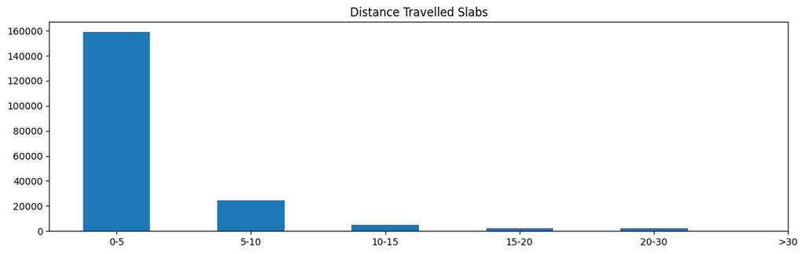

```python
def return_kmslab(km):
    if km < 5: return '0-5'
    if (km >= 5) & (km < 10): return '5-10'
    if (km >= 10) & (km < 15): return '10-15'
    if (km >= 15) & (km < 20): return '15-20'
    if (km >= 20) & (km < 30): return '20-30'
    if (km >= 30): return '>30'

plt.figure(figsize = (14,4))
plt.hist(uber.distance_travelled.apply(return_kmslab), align ='left')
plt.title('Distance Travelled Slabs')
plt.show()
```

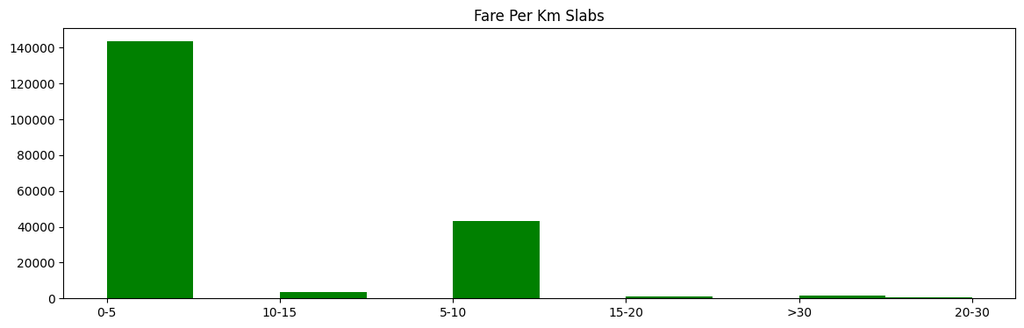

```python
def return_fareslab(fare):
    if fare < 5: return '0-5'
    if (fare >= 5) & (fare < 10): return '5-10'
    if (fare >= 10) & (fare < 15): return '10-15'
    if (fare >= 15) & (fare < 20): return '15-20'
    if (fare >= 20) & (fare < 30): return '20-30'
    if (fare >= 30): return '>30'

plt.figure(figsize = (14,4))
plt.hist(uber.fare_per_km.apply(return_fareslab), color = 'g')
plt.title('Fare Per Km Slabs')
plt.show()
```

`We will be dropping rows that meets the below conditions. Outliers are found to be most concentrated in these regions`

- Distance Travelled less than 0.5 Km and greater than 30 Km
- Fare Per Km less than 0.5 US dollars and greater than 15 US dollars

```python
uber.drop(uber[(uber.fare_per_km < 0.5) | (uber.fare_per_km > 15)].index, inplace = True)
uber.drop(uber[(uber.distance_travelled < 0.5) | (uber.distance_travelled > 30)].index, inplace = True)
```

#### 5. Data Rearranging

```python
# Creating a field with pickup year for analysing
uber['pickup_year'] = uber['pickup_datetime'].apply(lambda x: x.year)
```

```python
uber['fare/km/passenger'] = uber['fare_per_km'] / uber['passenger_count']
```

```python
uber = uber[['pickup_year', 'pickup_datetime', 'passenger_count', 'distance_travelled', 'fare_amount' ,'fare/km/passenger', 'fare_per_km']]
uber.drop('pickup_datetime', axis = 'columns', inplace = True)
print(f"The dataset after wrangling has {uber.shape[0]} rows and {uber.shape[1]} columns\n")
uber.head()
```

```
The dataset after wrangling has 186539 rows and 6 columns
```

|  | pickup_year | passenger_count | distance_travelled | fare_amount | fare/km/passenger | fare_per_km |
| --- | --- | --- | --- | --- | --- | --- |
| 0 | 2015 | 1.0 | 1.683323 | 7.5 | 4.455474 | 4.455474 |
| 1 | 2009 | 1.0 | 2.457590 | 7.7 | 3.133151 | 3.133151 |
| 2 | 2009 | 1.0 | 5.036377 | 12.9 | 2.561365 | 2.561365 |
| 3 | 2009 | 3.0 | 1.661683 | 5.3 | 1.063179 | 3.189536 |
| 4 | 2014 | 5.0 | 4.475450 | 16.0 | 0.715012 | 3.575060 |

## IV. Data Visualization and Insights

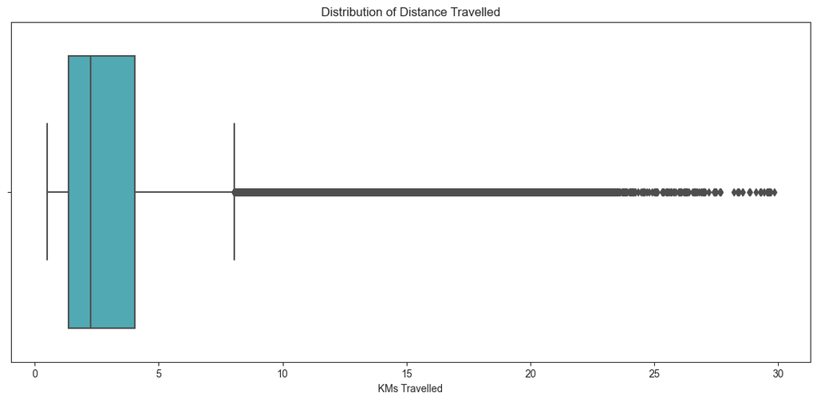

```python
plt.figure(figsize = (14,6))
sns.set_style('ticks')

sns.boxplot(data = uber, x = 'distance_travelled', palette = 'YlGnBu')

plt.title('Distribution of Distance Travelled')
plt.xlabel('KMs Travelled')
plt.show()
```

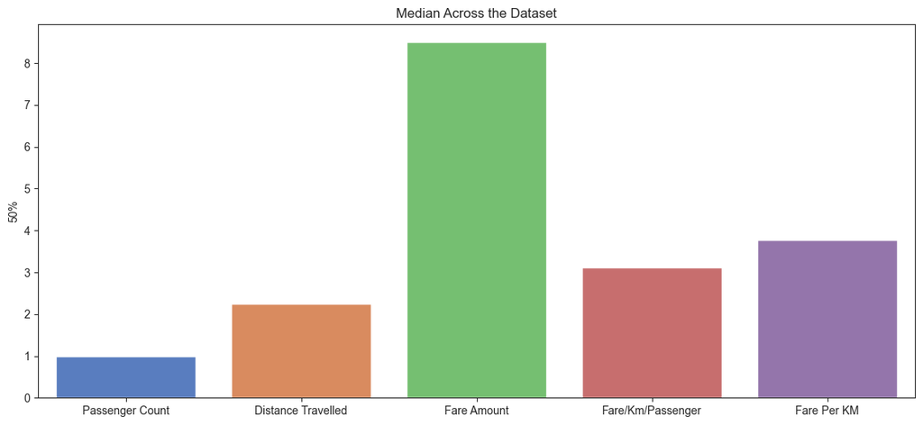

```python
plt.figure(figsize = (14,6))
sns.barplot(x = uber.describe(include = ['float']).loc['50%'].index, y = uber.describe(include = ['float']).loc['50%'], palette = 'muted')
plt.title('Median Across the Dataset')
plt.xticks([0,1,2,3,4], ['Passenger Count', 'Distance Travelled', 'Fare Amount', 'Fare/Km/Passenger', 'Fare Per KM'])
plt.show()
```

```python
year = uber.groupby('pickup_year')
plt.style.use('ggplot')
```

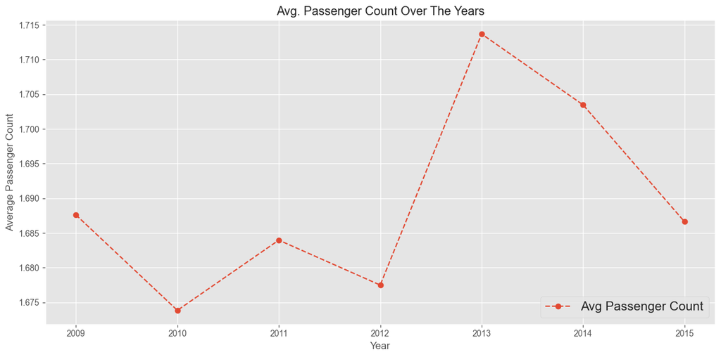

```python
x = year.agg('mean')['passenger_count'].index
y = year.agg('mean')['passenger_count']

plt.figure(figsize = (12,6))
plt.plot(x, y, marker = 'o', linestyle = "--", label = 'Avg Passenger Count')
plt.xlabel('Year')
plt.ylabel('Average Passenger Count')
plt.legend(loc = 'lower right', fontsize = 15)
plt.title('Avg. Passenger Count Over The Years')

plt.tight_layout()
plt.show()
```

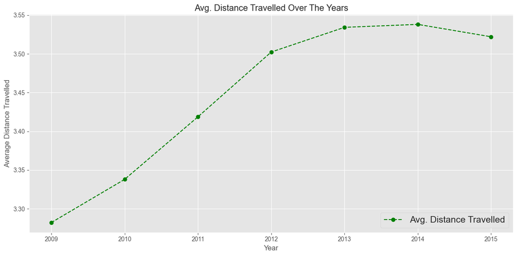

```python
x = year.agg('mean')['distance_travelled'].index
y = year.agg('mean')['distance_travelled']

plt.figure(figsize = (12,6))
plt.plot(x, y, marker = 'o', linestyle = "--", color = 'g', label = 'Avg. Distance Travelled')
plt.xlabel('Year')
plt.ylabel('Average Distance Travelled')
plt.legend(loc = 'lower right', fontsize = 15)
plt.title('Avg. Distance Travelled Over The Years')

plt.tight_layout()
plt.show()
```

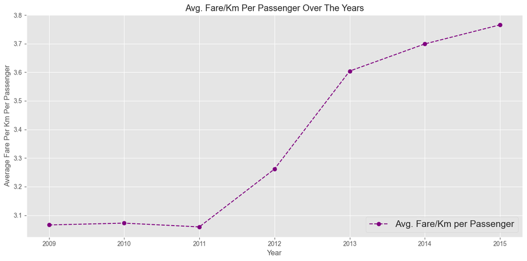

```python
x = year.agg('mean')['fare/km/passenger'].index
y = year.agg('mean')['fare/km/passenger']

plt.figure(figsize = (12,6))
plt.plot(x, y, marker = 'o', linestyle = "--", color = 'purple', label = 'Avg. Fare/Km per Passenger')
plt.xlabel('Year')
plt.ylabel('Average Fare Per Km Per Passenger')
plt.legend(loc = 'lower right', fontsize = 15)
plt.title('Avg. Fare/Km Per Passenger Over The Years')

plt.tight_layout()
plt.show()
```

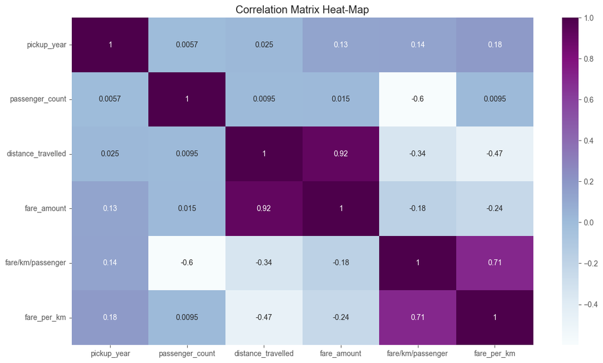

```python
plt.figure(figsize = (14, 8))
sns.heatmap(uber.corr(), annot = True, cmap = 'BuPu')
plt.yticks(rotation = 0)
plt.title('Correlation Matrix Heat-Map')
plt.show()
```

## V. Machine Learning

#### Splitting the Dataset

```python
uber.head()
```

|  | pickup_year | passenger_count | distance_travelled | fare_amount | fare/km/passenger | fare_per_km |
| --- | --- | --- | --- | --- | --- | --- |
| 0 | 2015 | 1.0 | 1.683323 | 7.5 | 4.455474 | 4.455474 |
| 1 | 2009 | 1.0 | 2.457590 | 7.7 | 3.133151 | 3.133151 |
| 2 | 2009 | 1.0 | 5.036377 | 12.9 | 2.561365 | 2.561365 |
| 3 | 2009 | 3.0 | 1.661683 | 5.3 | 1.063179 | 3.189536 |
| 4 | 2014 | 5.0 | 4.475450 | 16.0 | 0.715012 | 3.575060 |

```python
X = uber.drop(['fare_amount', 'fare/km/passenger', 'fare_per_km'], axis = 'columns')
y = uber['fare_amount']
```

```python
X_train, X_test, y_train, y_test = train_test_split(X, y, test_size = 0.3, random_state = 0)
```

#### Using Linear Regression Algorithm

```python
LR = LinearRegression()

LR.fit(X_train, y_train)
y_pred1 = LR.predict(X_test)

LR_score = r2_score(y_test, y_pred1)
print(f'The R\u00B2 score for Linear Regression is {(LR_score * 100).round(2)}%')
```

```
The R² score for Linear Regression is 85.42%
```

#### Using Decision Tree Regressor Algorithm

```python
DT = DecisionTreeRegressor()

DT.fit(X_train, y_train)
y_pred2 = DT.predict(X_test)

DT_score = r2_score(y_test, y_pred2)
print(f'The R\u00B2 score for Linear Regression is {(DT_score * 100).round(2)}%')
```

```
The R² score for Linear Regression is 73.14%
```

#### Using Random Forest Regressor Algorithm

```python
RF = RandomForestRegressor()

RF.fit(X_train, y_train)
y_pred3 = RF.predict(X_test)

RF_score = r2_score(y_test, y_pred3)
print(f'The R\u00B2 score for Linear Regression is {(RF_score * 100).round(2)}%')
```

```
The R² score for Linear Regression is 82.72%
```

#### Using Gradient Boosting Regressor Algorithm

```python
GB = GradientBoostingRegressor()

GB.fit(X_train, y_train)
y_pred4 = GB.predict(X_test)

GB_score = r2_score(y_test, y_pred4)
print(f'The R\u00B2 score for Linear Regression is {(GB_score * 100).round(2)}%')
```

```
The R² score for Linear Regression is 86.75%
```

## VI. Comparing Model Performance

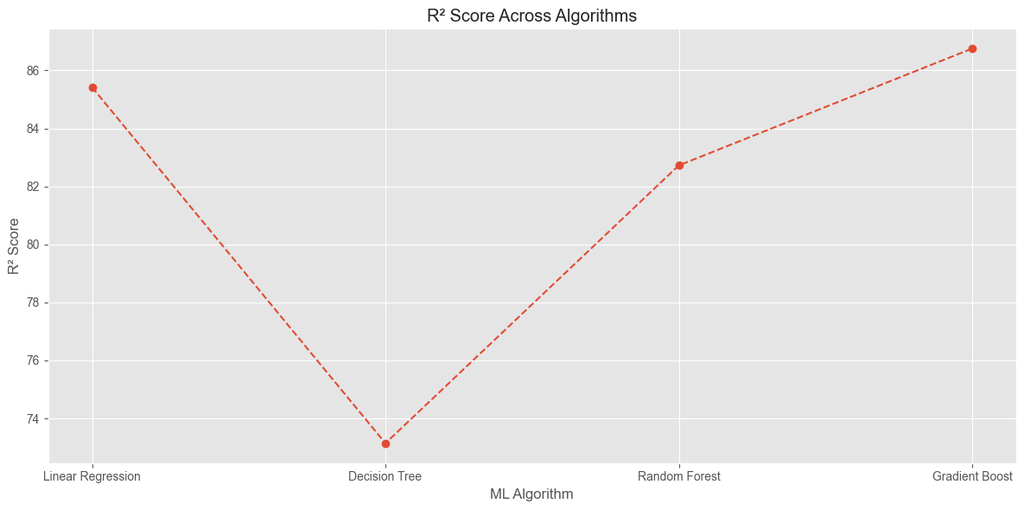

```python
plt.figure(figsize = (12,6))
plt.title('R\u00B2 Score Across Algorithms')
plt.plot(["Linear Regression", "Decision Tree", "Random Forest", "Gradient Boost"], np.array([LR_score, DT_score, RF_score, GB_score]) * 100, marker = 'o', linestyle = '--')
plt.xlabel('ML Algorithm')
plt.ylabel('R\u00B2 Score')


plt.savefig('Charts/Rsquared score.png', dpi = 96)
plt.tight_layout()
plt.show()
```

### Model Implementation

```python
model = joblib.dump(GB, 'fare_predictor')
```

```python
fare_predictor = joblib.load(model[0])
```

### Predicting Fare Price

```python
pickup_year = int(input("Enter the Pickup Year: "))
passenger_count = int(input("Enter the Passenger Count: "))
distance_travelled = float(input("Enter the Distance Travelled(in Kms): "))

fare_amount =  fare_predictor.predict(pd.DataFrame({
    'pickup_year': pickup_year,
    'passenger_count': passenger_count,
    'distance_travelled': distance_travelled
}, index = [0]))

print(f'The Fare Price Prediction for the given parameters is {fare_amount[0].round(2)}$\n')
pd.DataFrame({
    'pickup_year': pickup_year,
    'passenger_count': passenger_count,
    'distance_travelled': distance_travelled,
    'fare_amount': fare_amount
}, index = [0])
```